# Mini Project: Monte Carlo Methods

In this notebook, you will write your own implementations of many Monte Carlo (MC) algorithms.

### Part 0: Explore BlackjackEnv

Use the code cell below to create an instance of the [Blackjack](https://github.com/openai/gym/blob/master/gym/envs/toy_text/blackjack.py) environment.

```python
import gym
env = gym.make('Blackjack-v0')
```

Each state is a 3-tuple of:

- the player's current sum $\in \{0, 1, \ldots, 31\}$,
- the dealer's face up card $\in \{1, \ldots, 11\}$, and
- whether or not the player has a usable ace (`no` $=0$, `yes` $=1$).

The agent has two potential actions:

```
    STICK = 0
    HIT = 1
```

Verify this by running the code cell below.

```python
print(env.observation_space)
print(env.action_space)
```

```
Tuple(Discrete(32), Discrete(11), Discrete(2))
Discrete(2)
```

Execute the code cell below to play Blackjack with a random policy.

(*The code currently plays Blackjack three times - feel free to change this number, or to run the cell multiple times. The cell is designed for you to get some experience with the output that is returned as the agent interacts with the environment.*)

```python
# set number of episodes desired
for i_episode in range(3):
    # begin new game
    state = env.reset()
    # loop
    while True:
        # current state
        print(state)
        # choose action to take (stick or hit)
        action = env.action_space.sample()
        # take action on environment
        # outputs next state, reward (-1, 0, 1), if action = stick or bust, information
        state, reward, done, info = env.step(action)
        # if stick (done) is true, break loop
        if done:
            print('End game! Reward: ', reward)
            print('You won :)\n') if reward > 0 else print('You lost :(\n')
            break
```

```
(14, 1, False)
End game! Reward:  -1
You lost :(

(18, 8, False)
End game! Reward:  -1
You lost :(

(20, 1, False)
End game! Reward:  -1
You lost :(
```

### Part 1: MC Prediction: State Values

In this section, you will write your own implementation of MC prediction (for estimating the state-value function).

We will begin by investigating a policy where the player always sticks if the sum of her cards exceeds 18. The function `generate_episode_from_limit` samples an episode using this policy.

The function accepts as **input**:

- `bj_env`: This is an instance of OpenAI Gym's Blackjack environment.

It returns as **output**:

- `episode`: This is a list of (state, action, reward) tuples (of tuples) and corresponds to $(S_0, A_0, R_1, \ldots, S_{T-1}, A_{T-1}, R_{T})$, where $T$ is the final time step. In particular, `episode[i]` returns $(S_i, A_i, R_{i+1})$, and `episode[i][0]`, `episode[i][1]`, and `episode[i][2]` return $S_i$, $A_i$, and $R_{i+1}$, respectively.

```python
def generate_episode_from_limit(bj_env):
    # initialize episode output to empty list
    episode = []
    # restart game
    state = bj_env.reset()
    # begin game loop
    while True:
        # if card sum bigger than 18, stick
        # anything less, hit
        action = 0 if state[0] > 18 else 1
        # take action
        next_state, reward, done, info = bj_env.step(action)
        # append new state outputs to episode list
        episode.append((state, action, reward))
        # save new state to state to begin next move
        state = next_state
        # if stick or bust, end game
        if done:
            break
    # return this game's details
    return episode
```

Execute the code cell below to play Blackjack with the policy.

```python
# play certain # games using range(# games)
for i in range(1):
    print(generate_episode_from_limit(env))
```

```
[((15, 9, True), 1, 0), ((17, 9, True), 1, 0), ((19, 9, True), 0, 0.0)]
```

Now, you are ready to write your own implementation of MC prediction. Feel free to implement either first-visit or every-visit MC prediction; in the case of the Blackjack environment, the techniques are equivalent.

- `env`: This is an instance of an OpenAI Gym environment.
- `num_episodes`: This is the number of episodes that are generated through agent-environment interaction.
- `generate_episode`: This is a function that returns an episode of interaction.
- `gamma`: This is the discount rate. It must be a value between 0 and 1, inclusive (default value: `1`).

The algorithm returns as output:

- `V`: This is a dictionary where `V[s]` is the estimated value of state `s`. For example, if your code returns the following output:

  ```
  {(4, 7, False): -0.38775510204081631, (18, 6, False): -0.58434296365330851, (13, 2, False): -0.43409090909090908, (6, 7, False): -0.3783783783783784, ...
  ```

  then the value of state `(4, 7, False)` was estimated to be `-0.38775510204081631`.

If you are unfamiliar with how to use `defaultdict` in Python, you are encouraged to check out [this source](https://www.accelebrate.com/blog/using-defaultdict-python/).

```python
from collections import defaultdict
import numpy as np
import sys

def mc_prediction_v(env, num_episodes, generate_episode, gamma=1.0):
    # initialize empty dictionary of lists
    returns = defaultdict(list)
    # loop over episodes
    for i_episode in range(1, num_episodes+1):
        # monitor progress
        if i_episode % 1000 == 0:
            print("\rEpisode {}/{}.".format(i_episode, num_episodes), end="")
            sys.stdout.flush()
        # begin episode (game)
        episode = generate_episode(env)
        # separate episode data into tuples of same information
        states, actions, rewards = zip(*episode)
        # discount rates given number of actions (moves)
        discounts = np.array([gamma ** i for i in range(len(actions) + 1)])
        # loop over episode's moves
        for i, state in enumerate(states):
            # given state append it's corresponding discounted reward values
            returns[state].append(sum(rewards[i:] * discounts[:-(i+1)]))
    # from returns dictionary, average values for all distinct states & store as dict V
    V = {state : np.mean(dis_r) for state, dis_r in returns.items()}
    # return final dictionary {state : discounted reward}
    return V
```

Use the cell below to calculate and plot the state-value function estimate. (*The code for plotting the value function has been borrowed from [this source](https://github.com/dennybritz/reinforcement-learning/blob/master/lib/plotting.py) and slightly adapted.*)

To check the accuracy of your implementation, compare the plot below to the corresponding plot in the solutions notebook **Monte_Carlo_Solution.ipynb**.

```
Episode 500000/500000.
```

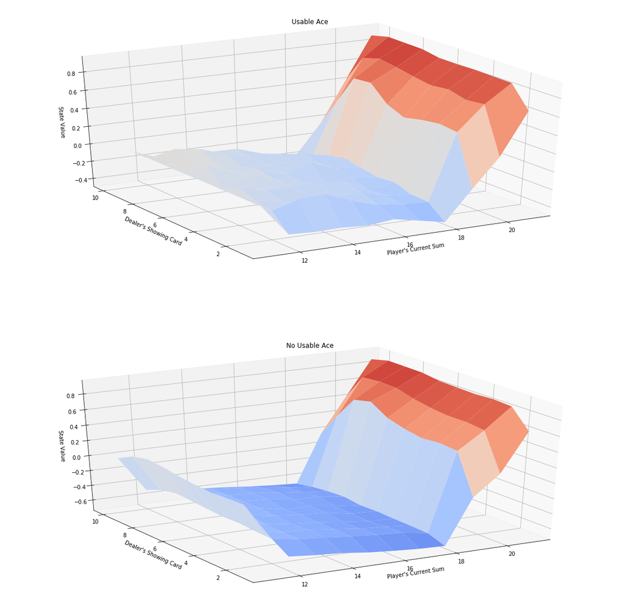

```python
from plot_utils import plot_blackjack_values

# obtain the value function
V = mc_prediction_v(env, 500000, generate_episode_from_limit)

# plot the value function
plot_blackjack_values(V)
```

### Part 2: MC Prediction: Action Values

In this section, you will write your own implementation of MC prediction (for estimating the action-value function).

We will begin by investigating a policy where the player *almost* always sticks if the sum of her cards exceeds 18. In particular, she selects action `STICK` with 80% probability if the sum is greater than 18; and, if the sum is 18 or below, she selects action `HIT` with 80% probability. The function `generate_episode_from_limit_stochastic` samples an episode using this policy.

The function accepts as **input**:

- `bj_env`: This is an instance of OpenAI Gym's Blackjack environment.

It returns as **output**:

- `episode`: This is a list of (state, action, reward) tuples (of tuples) and corresponds to $(S_0, A_0, R_1, \ldots, S_{T-1}, A_{T-1}, R_{T})$, where $T$ is the final time step. In particular, `episode[i]` returns $(S_i, A_i, R_{i+1})$, and `episode[i][0]`, `episode[i][1]`, and `episode[i][2]` return $S_i$, $A_i$, and $R_{i+1}$, respectively.

```python
def generate_episode_from_limit_stochastic(bj_env):
    # initialize episode (game) data to empty list
    episode = []
    # begin with a new state (new game)
    state = bj_env.reset()
    # start episode
    while True:
        # define [stick, hit] probabilities
        # given current state sum
        probs = [0.8, 0.2] if state[0] > 18 else [0.2, 0.8]
        # select action to using action probs conditions
        action = np.random.choice(np.arange(2), p=probs)
        # take action and get output
        next_state, reward, done, info = bj_env.step(action)
        # store current state, action and reward in episode list
        episode.append((state, action, reward))
        # update state after action
        state = next_state
        # if stick or bust
        if done:
            break
    # return game summary
    return episode
```

Now, you are ready to write your own implementation of MC prediction. Feel free to implement either first-visit or every-visit MC prediction; in the case of the Blackjack environment, the techniques are equivalent.

- `env`: This is an instance of an OpenAI Gym environment.
- `num_episodes`: This is the number of episodes that are generated through agent-environment interaction.
- `generate_episode`: This is a function that returns an episode of interaction.
- `gamma`: This is the discount rate. It must be a value between 0 and 1, inclusive (default value: `1`).

The algorithm returns as output:

- `Q`: This is a dictionary (of one-dimensional arrays) where `Q[s][a]` is the estimated action value corresponding to state `s` and action `a`.

```python
def mc_prediction_q(env, num_episodes, generate_episode, gamma=1.0):
    # initialize empty dictionaries of arrays
    returns_sum = defaultdict(lambda: np.zeros(env.action_space.n))
    N = defaultdict(lambda: np.zeros(env.action_space.n))
    Q = defaultdict(lambda: np.zeros(env.action_space.n))
    # loop over episodes
    for i_episode in range(1, num_episodes+1):
        # monitor progress
        if i_episode % 1000 == 0:
            print("\rEpisode {}/{}.".format(i_episode, num_episodes), end="")
            sys.stdout.flush()
        # generate one episode (game)
        episode = generate_episode(env)
        # separate states, actions and rewards from episode's visits
        states, actions, rewards = zip(*episode)
        # generate discount values array for every action taken
        discounts = np.array([gamma ** move for move in range(len(actions) + 1)])
        # loop over states seen in episode
        for i, state in enumerate(states):
            # add discounted reward to state-action dictionary
            returns_sum[state][action] += sum(rewards[i:] * discounts[:-(i+1)])
            # count number of visits for state-action pair
            N[state][action] += 1
            # average reward value for given state-action pair
            Q[state][action] = returns_sum[state][action] / N[state][action]
    # get final average state-action values
    return Q
```

Use the cell below to obtain the action-value function estimate $Q$. We have also plotted the corresponding state-value function.

To check the accuracy of your implementation, compare the plot below to the corresponding plot in the solutions notebook **Monte_Carlo_Solution.ipynb**.

```
Episode 500000/500000.
```

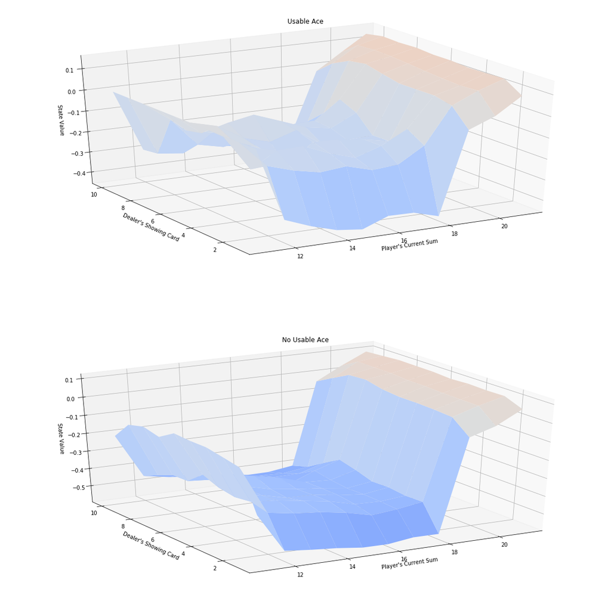

```python
# obtain the action-value function
Q = mc_prediction_q(env, 500000, generate_episode_from_limit_stochastic)

# obtain the state-value function
V_to_plot = dict((k,(k[0]>18)*(np.dot([0.8, 0.2],v)) + (k[0]<=18)*(np.dot([0.2, 0.8],v))) \
         for k, v in Q.items())

# plot the state-value function
plot_blackjack_values(V_to_plot)
```